# TE Chpt 16 HW - Fixed Effects

Fatima Fairfax

3/3/2022

# Theory Homework

```r
library(tidyverse)
```

## How Does it Work?

### Question 1

**You observe the number of vacations taken by Zac and Skylar in 2012, 2013, and 2014. In those years, Zac took 3, 7, and 5 vacations, respectively. Skylar took 2, 6, and 10.**

```r
#just to visualize this'
yrs <- c(2012,2013,2014)
zac_vc <- c(3,7,5)
sky_vc <- c(2,6,10)

q1 <- data.frame(yrs,zac_vc,sky_vc)

q1
```

```
##    yrs zac_vc sky_vc
## 1 2012      3      2
## 2 2013      7      6
## 3 2014      5     10
```

**a. Isolate the numbers that represent the variation between Zac and Skylar in their vacation-taking.**

Between variation looks that the difference between individuals in the mean. So we can add another column that gets the average for each individual and get the difference between those averages:

```r
avg_z <- mean(q1$zac_vc)

avg_s <-  mean(q1$sky_vc)

btwn <- avg_z - avg_s

btwn
```

```
## [1] -1
```

The mean for Zac is 5 vacations and the mean for Skylar is 6 vacations. So the between variation is -1, or 1 taking the absolute value.

**b. Isolate the variation within Zac and within Skylar in their vacation-taking.**

The within variation looks at the difference between each indivual’s mean and their observed value for the year.

```r
q1 <- q1 |>
  mutate(zac_within = zac_vc - avg_z,
         sky_within = sky_vc - avg_s)

q1
```

```
##    yrs zac_vc sky_vc zac_within sky_within
## 1 2012      3      2         -2         -4
## 2 2013      7      6          2          0
## 3 2014      5     10          0          4
```

So the within variation for Zac compares the fact that in 2012, he took 2 less vacations than average, in 2013 he took 2 more vacations than average, and in 2014 he took the average amount of vacations for him.

For Skylar, it compares the fact that in 2012 she took 4 less vacations than average, in 2013 she took an average amount of vacations, and in 2014 took 4 more vacations than average.

**c. (Difficult!) We perform a fixed effects analysis of the effect of vacations on happiness. A vacation increases Zac’s happiness by 1 “happiness point,” but it increases Skylar’s happiness by 2 “happiness points.” Will our fixed effects estimate likely give us an answer closer to 1, closer to 2, or exactly 1.5?**

Skylar has more within variation over the time period, which is weighted more heavily in the fixed effect estimation. So the value would be closer to 2.

### Question 2

**You are interested in the effect of cultural events on the levels of trust in a city. Perhaps big events like concerts bring people together and they can trust each other more. You plan to look at the relationship between trust and number of events in a given year, with fixed effects for city. Draw a causal diagram for this research question with at least four back door paths. Which paths will be closed by fixed effects, and which will remain open?**

The main relationship of interest here is between number of events in a year and trust within a city. Some factors that might influence number of events are:

- population of the city (bigger cities might have more events)
- navigability of the city (if it’s easy to get around)
- amount of creative or artistic people in the city (to stage events)
- income of the city (populations that can spend money on events)
- an effective city counsel (to sanction and help organize big events)

All of those can also effect the level of trust in a city:

- population (more people = more people you don’t know / have a relationship with)
- navigability (good public transit means you can build relationships)
- amount of creative people (maybe creative people are more trusting?)
- income of the city (people have different base levels of trust depending on how they perceive the communities)
- effective city counsel (structures in place might make people more trusting)

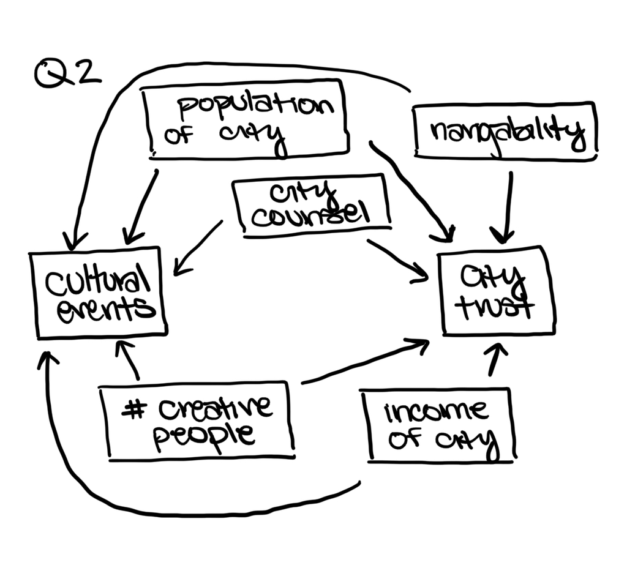

Fixed Effects Q2

Using fixed effects, and a couple of assumptions, we can close a few of these backdoor paths. The assumption we will take is that over the time of our study data cities do not change too much structurally (i.e., new roads or sidewalks aren’t being erected) and the population number and demographics stays fairly stable. These assumptions allow us to close more doors, whereas in reality all of these variables could be time-varying. But we will isolate the ones that seem more resistant to change in the intermediate term.

Taking the above, the backdoor paths that we can close are 1) navigability of the city, 2) population of the city, 3) income of the city and 4) number of creative people. This last one seems the most tenuous, as you could have younger people growing up who are more creative or people moving in who are more creative, but under the assumption that creative people come about to a city at random and their numbers may stay fairly consistent in any one location we’ll call this a time-constant variable for the sake of this study.

The city counsel variable is one that we cannot close, assuming that city counsel members get elected on cycles and predictably change with semi-frequency over the course of a few years.

### Question 3

**Classify each of the following forms of variation as “between variation”, “within variation”, or a combination of both.**

1. (Individual = person) How a child’s height changes as they age. **within variation**
2. (Individual = person) In a data set tracking many people over many years, the variation in the number of children a person has in a given year. **within variation**
3. (Individual = city) Overall, Paris, France has more restaurants than Paris, Texas. **between variation**
4. (Individual = genre) The average pop music album sells more copies than the average jazz album **between variation**
5. (Individual = genre) Miles Davis’ Kind of Blue sold very well for a jazz album. **combination of within (within the jazz genre) and between (considering the genre against others)**
6. (Individual = genre) Michael Jackson’s Thriller, a pop album, sold many more copies than Kind of Blue, a jazz album **between variation**

### Question 4

**Why does the process of taking each observation relative to its individual-level mean have the effect of “controlling for individual”?**

When we take observations relative to the individual level mean we are only looking at the within unit variation. This has the effect of holding all observed and unobserved confounding time-constant variables constant, so that those factors specific to the individual are no longer influencing the dependent variable.

## How is it performed?

### Question 5

**You are interested in the effect of cultural events on the levels of trust in a city. You run a regression of trust levels (on a 0-100 scale) on the number of cultural events with city fixed effects and get a coefficient on cultural events of 3.6. Assume that there are still some back doors open, so do not interpret the result causally. Interpret the 3.6, explaining it in an English sentence**

The coefficient of 3.6 in this fixed effects model means that, for a given city where the number cultural events are one unit higher than it typically is for that city, we’d expect trust levels to be 3.6 higher than is typical for that city.

### Question 6

**You are interested in the effect of cultural events on the levels of trust in a city. You run a regression of trust levels (on a 0-100 scale) on the number of cultural events with city and year fixed effects and get a coefficient on cultural events of 2.4. Assume that there are still some back doors open, so do not interpret the result causally. Interpret the 2.4, explaining it in an English sentence**

The coefficient of 2.4 in this fixed effects model means that, for a given city in a given year where the number of cultural events is one unit higher than it typically is for that city, we’d expect trust levels to be 2.4 higher than is typical for that city.

### Question 7

**Two-way fixed effects with terms for both individual and time are often referred to as “controlling for individual and time effects”. Why might a researcher want to do this rather than just taking individual fixed effects and adding a linear/polynomial/etc. term for time?**

Having two-way fixed effects for both individual and time allows us to look at the *within* variation for both the individual and the time period, again isolating within variation and closing backdoors. If we were to simply add a term for time, we will miss how the individual fixed effects and the year fixed effect affect each other.

### Question 8

**Which of the following explains why random effects is likely to do a better job of estimating the individual-level effects than fixed effects, if its assumptions hold?**

1. Because it makes the assumption that the individual effects are unrelated to the other predictors, which breaks that back door and thus reduces bias.
2. Because random effects allows some amount of between variation into the model, and some of the real individual effect is that between variation.

   However, the chapter does note that one of the primary advantages of random effects over fixed effects is that, instead of just using within variation, it uses a weighted average of within and between variation.

**c. Because it uses the information from the entire data set to estimate each individual effect, rather than relying on only a few observations per individual.**

```
In the chapter, it notes that random effects allows us to use **all** data to estimate the distribution which improves the indiviudal effects estimation, which gives support to this answer.
```

4. It won’t. Enforcing Durbin-Wu-Hausman makes both methods produce the same estimates anyway

# Coding Homework

First, load the packages we’ll need:

```r
library(tidyverse)
library(modelsummary)
library(fixest)
library(wooldridge)
```

## Coding 1

**Load the data file as mp and limit the variables to: distid, year, math4, expp, and lunch**

distid - district identifier

year

math4 - percentage of 4th grade students who are satisfactory or better in math

expp - expenditure per pupil

lunch - percentage of students eligible for free lunch

```r
mp <- read.csv('https://raw.githubusercontent.com/NickCH-K/TheEffectAssignments/main/mathpnl.csv')

mp <- mp |> select(distid,year,math4,expp,lunch)

glimpse(mp)
```

```
## Rows: 3,850
## Columns: 5
## $ distid <int> 1010, 1010, 1010, 1010, 1010, 1010, 1010, 2010, 2010, 2010, 201…
## $ year   <int> 1992, 1993, 1994, 1995, 1996, 1997, 1998, 1992, 1993, 1994, 199…
## $ math4  <dbl> 28.8, 32.3, 39.1, 68.0, 68.4, 49.0, 75.0, 30.0, 28.6, 37.5, 40.…
## $ expp   <int> 4227, 4809, 5214, 6019, 6155, 6134, 6476, 3445, 3446, 3583, 852…
## $ lunch  <dbl> 36.30, 39.20, 38.60, 37.41, 40.79, 43.84, 42.61, 36.40, 38.60, …
```

## Coding 2

**Panel data is often described as “N by T”. That is, the number of different individuals N and the number of time periods T. Write code that outputs what N and T are in this data**

```r
N <- nrow(mp)

t_val <- unique(mp$year)

t_len <- length(t_val)

print(paste("N = ", N, "T = ", t_len))
```

```
## [1] "N =  3850 T =  7"
```

## Coding 3

**A balanced panel is one in which each individual shows up in every single time period. You can check whether a data set is a balanced panel by seeing whether the number of unique time periods each individual ID shows up in is the same as the number of unique time periods, or whether the number of unique individual IDs in each time period is the same as the total number of unique individual IDs. Think to yourself a second about why these procedures would check that this is a balanced panel. Then, check whether this data set is a balanced panel**

```
This procedure would allow me to see that every individual is represented in each time frame and that each time frame is represented in each individual. Since we know the unique time periods, we know all time periods that occur in the dataset. So if an individual has the same number of unique time periods, and we know the number of unique time periods in the total set, we know those time periods for the indiviudal can only be the unique time periods for the full data set (because they are the only ones that exist).

As we found above, there are 7 unique time periods in this data set. And with 3850 unique indiviudal rows, we should have 3850 / 7 unique indiviudals = 550.
```

```r
#check number of unique ids in the data set

length(unique(mp$distid))
```

```
## [1] 550
```

```
Yep, gives 550.
```

```r
#show how many observations are in the same year

table(mp$year)
```

```
##
## 1992 1993 1994 1995 1996 1997 1998
##  550  550  550  550  550  550  550
```

```
This shows that each year has the same amount of observations (550) which is a good sign, because that is the number of unique IDs we have.
```

```r
#check the reverse (number of individuals)

table(mp$distid)
```

[output not shown]

[output cut: 72 more lines]

```
This shows that they are all 7, which is great. But I don't want to print this 550 times. So I'm going to try and think of a check that might get here as well
```

```r
#check reverse without printing all 550 cases

id_tab <- table(mp$distid)

unique(id_tab)
```

```
## [1] 7
```

```
This shows that the only value that occurs in the value of number of unique years for each distinct id is 7, which again confirms that this is a balanced panel.
```

## Coding 4

**Run an OLS regression with no fixed effects of math4 on expp and lunch. Store the results as ml**

```r
library(tidyverse)
library(broom)
library(rstanarm)
library(broom.mixed)
options(mc.cores = parallel::detectCores())
```

```r
#regular linear

m1 <- lm(math4 ~ expp + lunch,
         data = mp)

summary(m1)
```

```
##
## Call:
## lm(formula = math4 ~ expp + lunch, data = mp)
##
## Residuals:
##     Min      1Q  Median      3Q     Max
## -72.401 -10.484   0.108  10.453  60.454
##
## Coefficients:
##               Estimate Std. Error t value Pr(>|t|)
## (Intercept) 29.5273165  1.1391190   25.92   <2e-16 ***
## expp         0.0069223  0.0001995   34.70   <2e-16 ***
## lunch       -0.3806213  0.0158601  -24.00   <2e-16 ***
## ---
## Signif. codes:  0 '***' 0.001 '**' 0.01 '*' 0.05 '.' 0.1 ' ' 1
##
## Residual standard error: 15.14 on 3847 degrees of freedom
## Multiple R-squared:  0.3078, Adjusted R-squared:  0.3075
## F-statistic: 855.4 on 2 and 3847 DF,  p-value: < 2.2e-16
```

[output not shown]

```r
#bayesian

bl <- stan_glm(math4 ~ expp + lunch,
               data = mp)

summary(bl)
```

```
##
## Model Info:
##  function:     stan_glm
##  family:       gaussian [identity]
##  formula:      math4 ~ expp + lunch
##  algorithm:    sampling
##  sample:       4000 (posterior sample size)
##  priors:       see help('prior_summary')
##  observations: 3850
##  predictors:   3
##
## Estimates:
##               mean   sd   10%   50%   90%
## (Intercept) 29.5    1.2 28.0  29.5  31.0
## expp         0.0    0.0  0.0   0.0   0.0
## lunch       -0.4    0.0 -0.4  -0.4  -0.4
## sigma       15.1    0.2 14.9  15.1  15.4
##
## Fit Diagnostics:
##            mean   sd   10%   50%   90%
## mean_PPD 55.4    0.4 55.0  55.4  55.9
##
## The mean_ppd is the sample average posterior predictive distribution of the outcome variable (for details see help('summary.stanreg')).
##
## MCMC diagnostics
##               mcse Rhat n_eff
## (Intercept)   0.0  1.0  4849
## expp          0.0  1.0  4850
## lunch         0.0  1.0  4981
## sigma         0.0  1.0  4441
## mean_PPD      0.0  1.0  4359
## log-posterior 0.0  1.0  1885
##
## For each parameter, mcse is Monte Carlo standard error, n_eff is a crude measure of effective sample size, and Rhat is the potential scale reduction factor on split chains (at convergence Rhat=1).
```

```
Here the intercept and beta values on lunch and expp are very similar to the regular linear model.
```

## Coding 5

**Modify the model in step 4 to include fixed effects for distid “by hand”. That is, subtract out the within-distid mean of math4, expp, and lunch, creating new variables math4_demean, expp_demean, and lunch_demean, and re-estimate the model using those variables, storing the result as m2**

```r
#by hand fixed effects
mp_fixed <- mp |>
  group_by(distid) |>
  mutate(math4_demean = math4 - mean(math4),
         expp_demean = expp - mean(expp),
         lunch_demean = lunch - mean(lunch)) |>
  ungroup()

#analyze within variation

m2 <- lm(math4_demean ~ expp_demean + lunch_demean,
         data = mp_fixed)

summary(m2)
```

```
##
## Call:
## lm(formula = math4_demean ~ expp_demean + lunch_demean, data = mp_fixed)
##
## Residuals:
##     Min      1Q  Median      3Q     Max
## -87.389  -6.438  -0.039   6.207  71.351
##
## Coefficients:
##               Estimate Std. Error t value Pr(>|t|)
## (Intercept)  4.761e-16  1.660e-01   0.000        1
## expp_demean  1.203e-02  2.139e-04  56.259  < 2e-16 ***
## lunch_demean 3.135e-01  5.025e-02   6.239 4.89e-10 ***
## ---
## Signif. codes:  0 '***' 0.001 '**' 0.01 '*' 0.05 '.' 0.1 ' ' 1
##
## Residual standard error: 10.3 on 3847 degrees of freedom
## Multiple R-squared:  0.4989, Adjusted R-squared:  0.4987
## F-statistic:  1915 on 2 and 3847 DF,  p-value: < 2.2e-16
```

[output not shown]

## Coding 6

**Next we’re going to estimate fixed effects by including distid as a set of dummies. This can be extremely slow, so for demonstration purposes use only the first 500 observations of your data (don’t get rid of the other observations, though, you’ll want them for the rest of this assignment). Run the model from step 4 but with dummies for different values of distid, saving the result as m3. Then, do a joint F test on the dummies (see Chapter 13), and report if you can reject that the dummies are jointly zero at the 99% level**

```r
short_mp <- head(mp,500)

glimpse(short_mp)
```

```
## Rows: 500
## Columns: 5
## $ distid <int> 1010, 1010, 1010, 1010, 1010, 1010, 1010, 2010, 2010, 2010, 201…
## $ year   <int> 1992, 1993, 1994, 1995, 1996, 1997, 1998, 1992, 1993, 1994, 199…
## $ math4  <dbl> 28.8, 32.3, 39.1, 68.0, 68.4, 49.0, 75.0, 30.0, 28.6, 37.5, 40.…
## $ expp   <int> 4227, 4809, 5214, 6019, 6155, 6134, 6476, 3445, 3446, 3583, 852…
## $ lunch  <dbl> 36.30, 39.20, 38.60, 37.41, 40.79, 43.84, 42.61, 36.40, 38.60, …
```

```r
m3 <- lm(math4 ~ factor(distid) + expp + lunch,
         data = short_mp)

summary(m3)
```

```
##
## Call:
## lm(formula = math4 ~ factor(distid) + expp + lunch, data = short_mp)
##
## Residuals:
##     Min      1Q  Median      3Q     Max
## -77.612  -7.529  -0.009   6.905  62.630
##
## Coefficients:
##                       Estimate Std. Error t value Pr(>|t|)
## (Intercept)         -2.966e+01  8.785e+00  -3.376 0.000802 ***
## factor(distid)2010  -1.289e+01  7.049e+00  -1.828 0.068196 .
## factor(distid)2020  -3.852e+01  7.497e+00  -5.138 4.23e-07 ***
## factor(distid)2070   3.061e+01  7.341e+00   4.169 3.70e-05 ***
## factor(distid)2080  -1.467e+00  6.897e+00  -0.213 0.831702
## factor(distid)3000   3.145e+01  7.765e+00   4.050 6.09e-05 ***
## factor(distid)3010   3.205e+01  8.353e+00   3.837 0.000143 ***
## factor(distid)3020   3.866e+01  7.806e+00   4.953 1.06e-06 ***
## factor(distid)3030   2.628e+01  7.612e+00   3.453 0.000610 ***
## factor(distid)3040   3.458e+01  7.894e+00   4.380 1.49e-05 ***
## factor(distid)3050   1.243e+00  7.054e+00   0.176 0.860201
## factor(distid)3060   1.560e+01  7.255e+00   2.150 0.032137 *
## factor(distid)3070   2.529e+01  7.809e+00   3.238 0.001296 **
## factor(distid)3080   1.140e+01  7.940e+00   1.436 0.151645
## factor(distid)3100   3.853e+01  8.727e+00   4.415 1.28e-05 ***
## factor(distid)3440   4.865e+01  1.027e+01   4.739 2.93e-06 ***
## factor(distid)4000   1.464e+01  6.959e+00   2.104 0.035966 *
## factor(distid)4010   1.844e+01  7.056e+00   2.614 0.009271 **
## factor(distid)5010  -3.416e+01  7.011e+00  -4.873 1.55e-06 ***
## factor(distid)5035   1.151e+01  7.068e+00   1.629 0.104107
## factor(distid)5040   3.618e+01  7.662e+00   4.722 3.18e-06 ***
## factor(distid)5060   3.389e+01  7.620e+00   4.447 1.11e-05 ***
## factor(distid)5065   1.220e+01  7.100e+00   1.718 0.086436 .
## factor(distid)5070   9.389e-01  6.902e+00   0.136 0.891857
## factor(distid)6010  -1.538e+01  7.040e+00  -2.185 0.029462 *
## factor(distid)6020   1.648e+01  7.003e+00   2.353 0.019096 *
## factor(distid)6050   9.037e+00  6.970e+00   1.297 0.195464
## factor(distid)7010  -1.245e+01  7.673e+00  -1.623 0.105279
## factor(distid)7040  -1.222e+00  6.910e+00  -0.177 0.859707
## factor(distid)8010   2.500e+01  7.211e+00   3.466 0.000581 ***
```

[output cut: 35 more lines]

```
## factor(distid)13110  3.566e+01  8.320e+00   4.287 2.25e-05 ***
## factor(distid)13120  2.918e+01  8.210e+00   3.554 0.000422 ***
## factor(distid)13130  1.680e+01  6.972e+00   2.409 0.016398 *
## factor(distid)13135  2.195e+01  7.180e+00   3.057 0.002374 **
## factor(distid)14010  2.740e+00  6.954e+00   0.394 0.693731
## factor(distid)14020  1.707e+01  6.923e+00   2.465 0.014080 *
## factor(distid)14030  1.514e+01  9.378e+00   1.614 0.107252
## expp                 8.839e-03  6.554e-04  13.486  < 2e-16 ***
## lunch                8.007e-01  1.933e-01   4.143 4.14e-05 ***
## ---
## Signif. codes:  0 '***' 0.001 '**' 0.01 '*' 0.05 '.' 0.1 ' ' 1
##
## Residual standard error: 12.9 on 426 degrees of freedom
## Multiple R-squared:  0.551,  Adjusted R-squared:  0.4741
## F-statistic: 7.162 on 73 and 426 DF,  p-value: < 2.2e-16
```

[output not shown]

```r
library(car)
#view the coefficient list

coef_3 <- as.data.frame(m3$coefficients)

coef_3
```

```
##                     m3$coefficients
## (Intercept)           -29.659078324
## factor(distid)2010    -12.887905903
## factor(distid)2020    -38.519654437
## factor(distid)2070     30.609134755
## factor(distid)2080     -1.466653569
## factor(distid)3000     31.446392454
## factor(distid)3010     32.052098433
## factor(distid)3020     38.660864338
## factor(distid)3030     26.283221827
## factor(distid)3040     34.578695713
## factor(distid)3050      1.243058174
## factor(distid)3060     15.596003468
## factor(distid)3070     25.288923299
## factor(distid)3080     11.404372137
## factor(distid)3100     38.534651857
## factor(distid)3440     48.652244759
## factor(distid)4000     14.640906447
## factor(distid)4010     18.442383248
## factor(distid)5010    -34.161982330
## factor(distid)5035     11.511617627
## factor(distid)5040     36.178257182
## factor(distid)5060     33.887188305
## factor(distid)5065     12.200923845
## factor(distid)5070      0.938891449
## factor(distid)6010    -15.378790498
## factor(distid)6020     16.475666298
## factor(distid)6050      9.036981966
## factor(distid)7010    -12.454920100
## factor(distid)7040     -1.221977719
## factor(distid)8010     24.996430847
## factor(distid)8030     31.327281481
## factor(distid)8050     27.042633946
## factor(distid)9010     10.541753702
## factor(distid)9030     32.608786182
## factor(distid)9050     28.588956724
## factor(distid)9090     15.755757963
## factor(distid)10015    13.916116484
## factor(distid)10025    14.419395101
## factor(distid)11000    21.331863651
```

[output cut: 20 more lines]

```
## factor(distid)13020   -29.099667752
## factor(distid)13050    18.361454607
## factor(distid)13070    34.718112328
## factor(distid)13080    25.202124906
## factor(distid)13090    31.129325523
## factor(distid)13095    12.236699655
## factor(distid)13110    35.664879014
## factor(distid)13120    29.180202791
## factor(distid)13130    16.800053745
## factor(distid)13135    21.950532265
## factor(distid)14010     2.740416979
## factor(distid)14020    17.068068699
## factor(distid)14030    15.136784600
## expp                    0.008838716
## lunch                   0.800728644
```

```r
#get the dimensions

dim(coef_3)
```

```
## [1] 74  1
```

```
It's showing up in the 1st, 73rd, and 74th rows (the ones we want to get rid of). So we'll keep 2 through 72.
```

```r
#to grab just the dummy variables without

coef_3 <- coef(m3)[2:72]
```

```r
#run the F test using the command from Chapter 13: linearHypothesis

## linearHypothesis(m3,hypothesis.matrix = coef(m3)[2:72], test = "F")
```

```
**Note to Nico** - This process continually gives me non-conformable arguements, even after checking with the class it does not seem to run when I remove the non-dummy variables, so I did run it also with all variables in tact:
```

```r
#run the F test using the command from Chapter 13: linearHypothesis

linearHypothesis(m3,hypothesis.matrix = m3$coefficients, test = "F")
```

```
## Linear hypothesis test
##
## Hypothesis:
## - 29.6590783243019 ((Intercept) - 12.8879059033499 factor(distid)2010 - 38.5196544371983 factor(distid)2020  + 30.6091347553326 factor(distid)2070 - 1.46665356901996 factor(distid)2080  + 31.4463924541086 factor(distid)3000  + 32.0520984327773 factor(distid)3010  + 38.6608643376358 factor(distid)…
##
## Model 1: restricted model
## Model 2: math4 ~ factor(distid) + expp + lunch
##
##   Res.Df   RSS Df Sum of Sq      F    Pr(>F)
## 1    427 76454
## 2    426 70858  1    5596.4 33.646 1.291e-08 ***
## ---
## Signif. codes:  0 '***' 0.001 '**' 0.01 '*' 0.05 '.' 0.1 ' ' 1
```

[output not shown]

## Coding 7

**Now we will use a specially-designed function to estimate a model with fixed effects. (Using the whole data set once again), use feols() from the fixest package in R to estimate the model from step 4 but with fixed effects for distid. Save the result as m4. Include standard errors clustered at the distid level**

```r
library(fixest)
```

```r
m4 <- feols(math4 ~ expp + lunch | distid,
              data = mp)

#standard errors are clustered by the first fixed effect by default (which is distid, which is what we want)
summary(m4)
```

```
## OLS estimation, Dep. Var.: math4
## Observations: 3,850
## Fixed-effects: distid: 550
## Standard-errors: Clustered (distid)
##       Estimate Std. Error  t value   Pr(>|t|)
## expp  0.012031   0.000486 24.73496  < 2.2e-16 ***
## lunch 0.313515   0.094000  3.33527 0.00090972 ***
## ---
## Signif. codes:  0 '***' 0.001 '**' 0.01 '*' 0.05 '.' 0.1 ' ' 1
## RMSE: 10.3     Adj. R2: 0.626328
##              Within R2: 0.498917
```

[output not shown]

## Coding 8

**Now add fixed effects for year to your model from step 7 to create a two-way fixed effects model. Keep the standard errors clustered at the distid level. Save the results as m5.**

```r
m5 <- feols(math4 ~ expp + lunch | distid + year,
            data = mp)

summary(m5)
```

```
## OLS estimation, Dep. Var.: math4
## Observations: 3,850
## Fixed-effects: distid: 550,  year: 7
## Standard-errors: Clustered (distid)
##        Estimate Std. Error   t value Pr(>|t|)
## expp  -0.000168   0.000710 -0.236864  0.81285
## lunch  0.018441   0.100154  0.184125  0.85398
## ---
## Signif. codes:  0 '***' 0.001 '**' 0.01 '*' 0.05 '.' 0.1 ' ' 1
## RMSE: 8.2812     Adj. R2: 0.757827
##                Within R2: 9.976e-5
```

[output not shown]

## Coding 9

**Using modelsummary() from modelsummary in R, make a regression table including m1 through m5 in the same table so you can compare them all. Read the documentation of your command to figure out how to include the expp, lunch, expp_demean, and lunch_demean predictors in the table without clogging the thing up with a bunch of dummy coefficients from m3.**

**Write down two interesting things you notice from the table. Multiple possible answers here**

```r
library(modelsummary)
```

```r
modelsummary(list(m1,m2,m3,m4,m5),
             coef_map = c('(Intercept)','expp','lunch','expp_demean','lunch_demean'),
             stars = TRUE)
```

|  | Model 1 | Model 2 | Model 3 | Model 4 | Model 5 |
| --- | --- | --- | --- | --- | --- |
| (Intercept) | 29.527*** | 0.000 | −29.659*** |  |  |
|  | (1.139) | (0.166) | (8.785) |  |  |
| expp | 0.007*** |  | 0.009*** | 0.012*** | 0.000 |
|  | (0.000) |  | (0.001) | (0.000) | (0.001) |
| lunch | −0.381*** |  | 0.801*** | 0.314*** | 0.018 |
|  | (0.016) |  | (0.193) | (0.094) | (0.100) |
| expp_demean |  | 0.012*** |  |  |  |
|  |  | (0.000) |  |  |  |
| lunch_demean |  | 0.314*** |  |  |  |
|  |  | (0.050) |  |  |  |
| Num.Obs. | 3850 | 3850 | 500 | 3850 | 3850 |
| R2 | 0.308 | 0.499 | 0.551 | 0.680 | 0.793 |
| R2 Adj. | 0.307 | 0.499 | 0.474 | 0.626 | 0.758 |
| R2 Within |  |  |  | 0.499 | 0.000 |
| R2 Pseudo |  |  |  |  |  |
| AIC | 31856.6 | 28888.4 | 4045.8 | 29984.4 | 28319.5 |
| BIC | 31881.6 | 28913.4 | 4361.9 | 33437.6 | 31810.3 |
| Log.Lik. | −15924.294 | −14440.199 | −1947.924 | −14440.199 | −13601.767 |
| F | 855.419 | 1915.184 | 7.162 |  |  |
| Std.Errors |  |  |  | by: distid | by: distid |
| FE: distid |  |  |  | X | X |
| FE: year |  |  |  |  | X |

+ p < 0.1, * p < 0.05, ** p < 0.01, *** p < 0.001

```r
#keep the variables and don't clog up the model summary with the coefficients from model 3
```

[output not shown]

## Coding 10

**Finally, we’ll close it out by using correlated random effects instead of fixed effects (see 16.3.3). You already have expp_demean and lunch_demean from earlier. Now, modify the code from that slightly to add on expp_mean and lunch_mean (the mean within distid instead of the value minus that mean). Then, regress math4 on expp_demean, lunch_demean, expp_mean, and lunch_mean, with random effects for distid using lmer() from lme4 in R. Show a summary of the regression results**

```r
library(lme4)
#by hand fixed effects
mp_fixed_2 <- mp |>
  group_by(distid) |>
  mutate(math4_demean = math4 - mean(math4),
         expp_demean = expp - mean(expp),
         lunch_demean = lunch - mean(lunch),
         expp_mean = mean(expp),
         lunch_mean = mean(lunch)) |>
  ungroup()

#analyze within variation

m6 <- lmer(math4 ~ expp_demean + lunch_demean + expp_mean + lunch_mean + (1 | distid),
         data = mp_fixed_2) #taking the formula from the example Steve gave in class

summary(m6)
```

```
## Linear mixed model fit by REML ['lmerMod']
## Formula: math4 ~ expp_demean + lunch_demean + expp_mean + lunch_mean +
##     (1 | distid)
##    Data: mp_fixed_2
##
## REML criterion at convergence: 30287
##
## Scaled residuals:
##     Min      1Q  Median      3Q     Max
## -7.9152 -0.5961  0.0061  0.5836  6.3543
##
## Random effects:
##  Groups   Name        Variance Std.Dev.
##  distid   (Intercept)  54.96    7.413
##  Residual             123.75   11.124
## Number of obs: 3850, groups:  distid, 550
##
## Fixed effects:
##                Estimate Std. Error t value
## (Intercept)  57.0350106  2.2281622  25.597
## expp_demean   0.0120310  0.0002310  52.090
## lunch_demean  0.3135149  0.0542746   5.776
## expp_mean     0.0019855  0.0003995   4.970
## lunch_mean   -0.4413807  0.0242230 -18.222
##
## Correlation of Fixed Effects:
##             (Intr) expp_d lnch_d expp_m
## expp_demean  0.000
## lunch_demen  0.000 -0.323
## expp_mean   -0.941  0.000  0.000
## lunch_mean  -0.303  0.000  0.000  0.007
```

```
Now for the random effects model. The advantage of the random effects model is that we can incorporate both the within variation from the fixed effects and the between variation. The 'demean' values are the within variation while the 'mean' values are the between variation.

Within districts, we expect a 0.01203 change in satisfactory 4th grader math percentage for increase in expenditures per pupil.
Within districts, we expect a 0.3135 change in satisfactory 4th grader math percentage for increase in percentage of students getting free lunch.

Between districts, we expect a 0.0019855 change in satisfactory 4th grader math percentage for increase in expenditures per pupil.
Between districts, we expect a -0.4413807 change in satisfactory 4th grader math percentage for increase in percentage of students getting free lunch.
```